# Fall 2019 Final Exam

Anne-Marie Parkinson

December 8, 2019

### Task 1: Predicting Penguin Mass

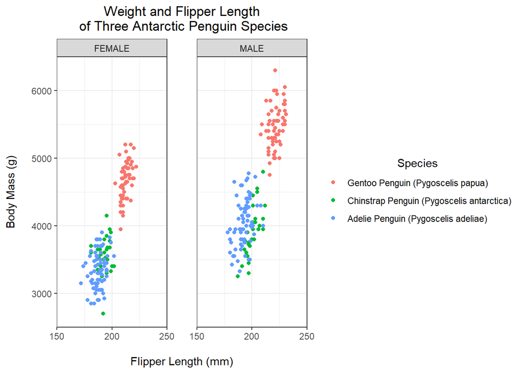

**Figure 1:** Flipper lengths (mm) and body mass (g) by sex of three penguin species in Antarctica - [Gentoo](https://doi.org/10.6073/pasta/409c808f8fc9899d02401bdb04580af7), [Chinstrap](https://doi.org/10.6073/pasta/2b1cff60f81640f182433d23e68541ce), and [Adelie](https://doi.org/10.6073/pasta/abc50eed9138b75f54eaada0841b9b86) penguins. Data: Palmer Station LTER.

General trends from Figure 1:

- Male penguins appear to have higher body mass and slightly longer flipper lengths than females across all three species.
- Gentoo penguins have the highest body mass and longest flipper length than Chinstrap and Adelie penguins.

**Table 1:** Regression table displaying the relationship between Antarctic penguins species, sex, and flipper length to predict body mass. body mass(sex, flipper length, species) = -365.8 + 530.38(MALE) + 20.03(flipper length) + 836.26(Gentoo Penguin) - 87.63(Chinstrap Penguin)

|  | *Dependent variable:* |
| --- | --- |
|  | body_mass_g |
| speciesChinstrap penguin (Pygoscelis antarctica) | -87.634* |
|  | (46.347) |
| speciesGentoo penguin (Pygoscelis papua) | 836.260*** |
|  | (85.185) |
| flipper_length_mm | 20.025*** |
|  | (2.846) |
| sexMALE | 530.381*** |
|  | (37.810) |
| Constant | -365.817 |
|  | (532.050) |
| Observations | 333 |
| R<sup>2</sup> | 0.867 |
| Adjusted R<sup>2</sup> | 0.865 |
| Residual Std. Error | 295.565 (df = 328) |
| F Statistic | 534.024*** (df = 4; 328) |
| *Note:* | p<0.1; p<0.05; p<0.01 |

The adjusted R<sup>2</sup> (R<sup>2</sup> = 0.865) evaluates how much variance in body mass is explained by the explanatory variables (species, flipper length, sex), so in this case 86.5% of the variance in penguin body mass can be explained by species, flipper length, and sex.

Interpretation of the model coefficients:

- If everything else about the penguin is the same (species, flipper length), then I expect male penguins to weigh 530.38 grams more than a female penguin on average
- If everything else is held constant, then I expect boby mass to increase 20.03 grams for every 1 mm increase in flipper length.
- If everything else about the penguin is the same (sex, flipper length), then I expect Gentoo penguins weigh 836.26 grams more than Adelie penguins.
- If everything else about the penguin is the same (sex, flipper length), then I expect Chinstrap penguins weigh 87.63 grams less than Adelie penguins.

**Table 2:** Predicted weights of three penguins (right column) using model: (body mass(sex, flipper length, species) = -365.8 + 530.38(MALE) + 20.03(flipper length) + 836.26(Gentoo Penguin) - 87.63(Chinstrap Penguin)

| Flipper Length (mm) | Sex | Species | Body Mass (g) Predictions |
| --- | --- | --- | --- |
| 195 | FEMALE | Chinstrap penguin (Pygoscelis antarctica) | 3451.407 |
| 205 | MALE | Adelie Penguin (Pygoscelis adeliae) | 4269.671 |
| 220 | MALE | Gentoo penguin (Pygoscelis papua) | 5406.305 |

### Task 2: Smoking effects on baby birth weight

**Table 3:** Data was collected on babies birthweight (categorically classified as low or not low) and whther or not the mother smoked during pregnancy. 1,000 babies from North Carolina were randomly selected for the study.

| Mother Smoke? | Low Birthweight? No | Low Birthweight? Yes |
| --- | --- | --- |
| No | 781 (89.5%) | 92 (10.5%) |
| Yes | 108 (85.7%) | 18 (14.3%) |

To improve future surveys, researchers might consider changing the “smoking during pregnancy” category from binomial (yes or no) to an ordinal response with more than two categories (e.g. frequently, sometimes, rarely, never). Some women might have smoked once or twice throughout their pregnancy, while others might have smoked every day, or some other frequency. Mothers who smoked once or twice may not have had as much of an effect on their babies birthweight than mothers who smoked frequently, so researchers would want to distinguish between these differences if there are any.

### Task 3: Visualizing UCSB campus profiles

In this section, I will explore the undergraduate enrollment rates of minorities at University of California, Santa barbara across all years of available data (2008-2019). Enrollment rates of whites, others, and unknowns were excluded from the analysis and some ethnicities were combined into similar groups (Filipinos were combined with Asian and Pacific Islanders, Chicanos and Latinos were combined into a new group called Hispanics).

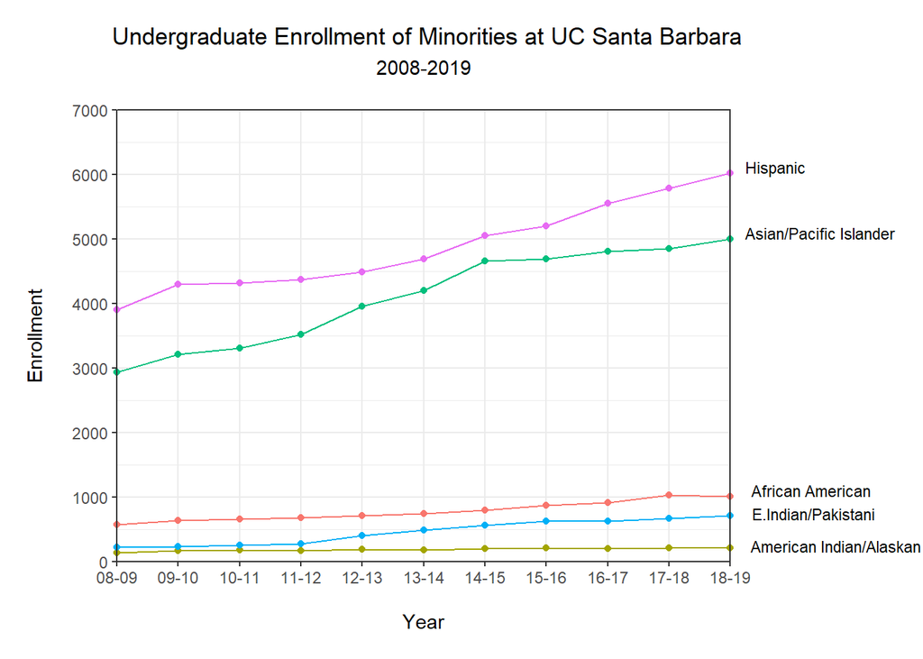

**Figure 2:** Annual undergraduate enrollment rates of minorities and underrepresented groups at University of California, Santa Barbara. Years are based on a school calendar year which starts in September of one year and ends in June of the following year. Data: [UCSB](http://bap.ucsb.edu/institutional.research/campus.profiles/)

General takeways from Figure 2:

- Hispanic and Asian/Pacific Islanders are the two most abundant minorities at UCSB, which have increased by 54% and 70%,respectively, since 2008.
- African American, E.Indian/Pakistani, and American Indian/Alaskan are the least represented minorities ar UCSB. Their combined enrollment is a fraction of Hispanic or Asian/Pacific Islander students. However, two groups, African Americans and E.Indian/Pakistani, have had a raster growth rate in enrollment (75% and 226% respectively) than Hispanic and Asian/Pacific Islanders.

### Task 4: Purple urchins on the Santa Barbara coast

**Table 4** Summary statistics for purple urchin (Strongylocentrotus purpuratus*) population sizes in control plots at five sites along the Santa Barbara coast from 2008-2018. Data: [SBC LTER](https://doi.org/10.6073/pasta/846569acc8745c133a44eac40245e6f0).*

| Site | Mean | Standard Deviation | Standard Error | Variance | Sample Size |
| --- | --- | --- | --- | --- | --- |
| Arroyo Quemado | 4.57 | 1.04 | 0.02 | 1.08 | 3185 |
| Carpinteria | 4.17 | 1.13 | 0.02 | 1.28 | 3430 |
| Isla Vista | 4.25 | 0.94 | 0.02 | 0.89 | 1601 |
| Mohawk | 5.28 | 1.14 | 0.02 | 1.30 | 3510 |
| Naples | 4.05 | 1.11 | 0.02 | 1.23 | 3219 |

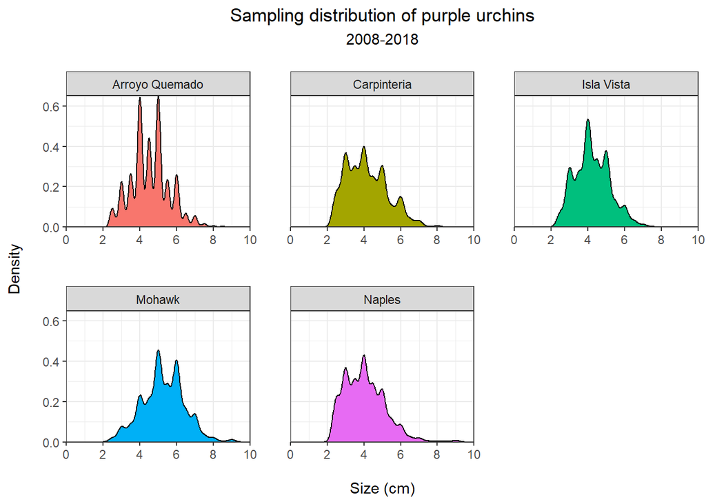

**Figure 3:** Sampling distributions of purple urchin (Strongylocentrotus purpuratus*) population sizes in control plots at five sites along the Santa Barbara coast. Sample size was combined with all samples collected from 2008 - 2018. Data: [SBC LTER](https://doi.org/10.6073/pasta/846569acc8745c133a44eac40245e6f0).*

Observed trends in sampe distribution graphs:

- Urchin sizes at Arroyo Quemado, Isla Vista, and Mohawk appear normally distributed.
- Urchin sizes at carpenteria and Naples are slightly right skewed.